# Séance 3 : Sous-ensembles et visualisation avec tidyverse

# 1 - Introduction

Au cours de cette séance, nous allons continuer à nous familiariser avec les packages du `tidyverse` et `ggplot2` pour explorer des données spatiales à l’échelle d’un site. Nous utiliserons le même jeu de données `jdd` que dans les séances 1 et 2.

Lors de la dernière séance, nous avons utilisé la fonction `plot()` native (ou plutôt générique) de R. Aujourd’hui nous allons utiliser la fonction `ggplot()`, issue de la bibliothèque du même nom dédiée à la visualisation dans R mais aussi dans d’autres languages de programmation comme Python.  
La fonction `ggplot()` est relativement intuitive, car elle fonctionne comme un système de calques dans illustrator. Par exemple:

```r
# utilisons le jeu de données d'exemple "iris"
head(iris)
```

```
##   Sepal.Length Sepal.Width Petal.Length Petal.Width Species
## 1          5.1         3.5          1.4         0.2  setosa
## 2          4.9         3.0          1.4         0.2  setosa
## 3          4.7         3.2          1.3         0.2  setosa
## 4          4.6         3.1          1.5         0.2  setosa
## 5          5.0         3.6          1.4         0.2  setosa
## 6          5.4         3.9          1.7         0.4  setosa
```

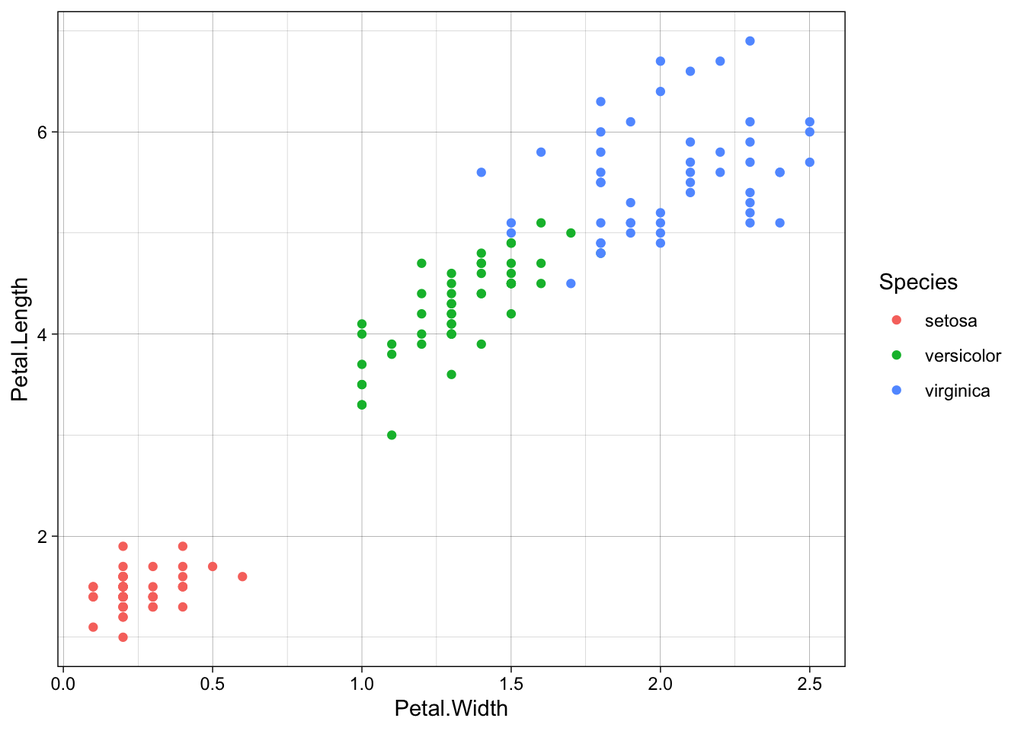

```r
p <- ggplot(data=iris,            # d'abord spécifier le jeu de données
               aes(x=Petal.Width,    # puis les variables x
                   y=Petal.Length,   # et y
                   color=Species)) + # on peut faire varier les couleurs et
                                     # les formes des points selon des variables
  geom_point() +                     # geom_point pour un nuage de point,
                                     # geom_bar pour des graph en barres,
                                     # geom_boxplot pour boîtes à moustaches, etc.
  theme_linedraw()                   # on peut aussi préciser un thème,
                                     # et toutes sortes d'autres choses...

p   # on a fait un objet graphique, on peut le projetter en tapant son nom
```

Note: en utilisant d’autres bibliothèques on peut ajouter des outils. Par exemple la bibliothèque `ggalt` a une fonction `geom_encircle()` que l’on peut appliquer à un sous-ensemble du jeu de données:

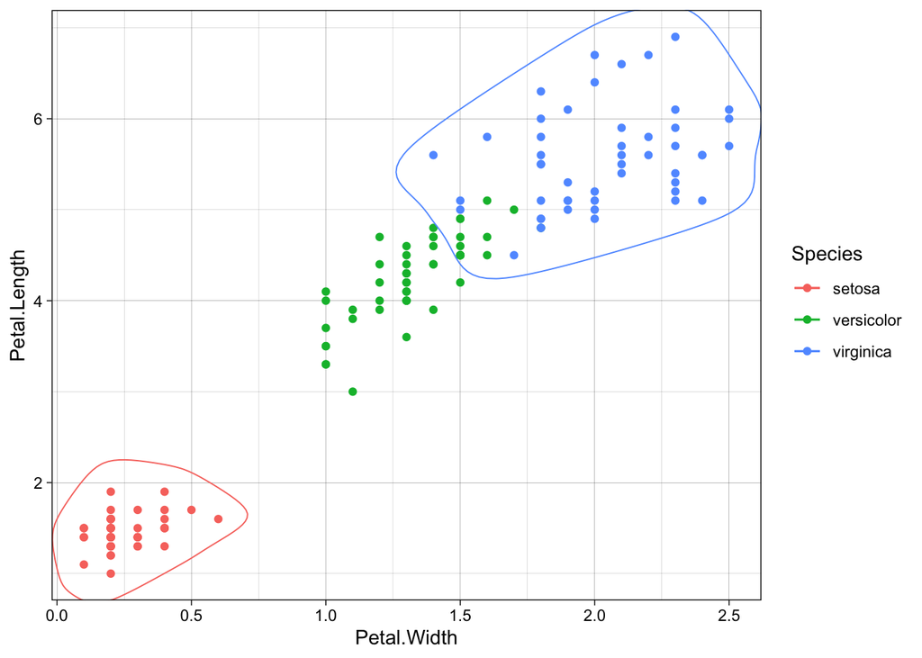

```r
setosa <- iris %>% dplyr::filter(Species == "setosa")
virginica <- iris %>% dplyr::filter(Species == "virginica")
p +
  geom_encircle(data = setosa, linetype = 1) +
  geom_encircle(data = virginica, linetype = 1)
```

# 2 - Créer un plan et un carroyage

Avant toute chose, revenons à notre jeu de données de la dernière fois:

```r
jdd <- as_tibble(read.csv("data/Data_exemple.csv", header = TRUE, sep = ","))
head(jdd)
```

```
## # A tibble: 6 × 8
##   numero type          x_cm  y_cm longueur_cm largeur_cm silex  raccord
##    <int> <chr>        <int> <int>       <dbl>      <dbl> <chr>    <int>
## 1      1 gravette        10    60         5          1.5 type A      NA
## 2      2 gravette        30    50         5.9        1.8 type C      NA
## 3      3 picardie        50    80         3.2        1.2 type B       1
## 4      4 percoir        260   100         4.7        2.1 type B      NA
## 5      5 burin          240   120         6          2.4 type B       2
## 6      6 burin diedre   280   150         8          3.5 type A      NA
```

Tout a l’air en ordre ! Nous pouvons donc commencer :)

Dans un premier temps, nous allons essayer de reproduire un plan de répartition spatiale X, Y, déjà réalisé avec QGIS et Powerpoint. Vous pouvez consulter ce plan dans le dossier `figures` du projet, sous le nom de `plan_exemple.pdf`. L’objectif de cet exercice est de créer un code que vous pourrez ensuite adapter à d’autres données. Cela vous permettra:  
1) de gagner un temps précieux, le code ne prenant que quelques secondes pour générer une figure ;  
2) d’avoir une unité graphique dans votre document en utilisant toujours le même layout ;  
3) d’organiser les différents éléments de vos figures toujours de la même façon.

Nous allons commencer par créer le carroyage du plan. D’après `plan_exemple.pdf`, la zone d’étude s’étend sur 16 carrés de 1 m de côté, organisés en 4 colonnes et 4 rangées. Vérifions tout d’abord les unités pour les coordonnées des points.

```r
summary(jdd)
```

```
##      numero       type                x_cm            y_cm        longueur_cm
##  Min.   : 1   Length:33          Min.   : 10.0   Min.   : 50.0   Min.   : 1.4
##  1st Qu.: 9   Class :character   1st Qu.: 50.0   1st Qu.: 90.0   1st Qu.: 4.5
##  Median :17   Mode  :character   Median :210.0   Median :280.0   Median : 5.9
##  Mean   :17                      Mean   :174.8   Mean   :217.6   Mean   : 5.8
##  3rd Qu.:25                      3rd Qu.:260.0   3rd Qu.:340.0   3rd Qu.: 7.4
##  Max.   :33                      Max.   :290.0   Max.   :390.0   Max.   :10.2
##
##    largeur_cm       silex              raccord
##  Min.   :0.500   Length:33          Min.   :1.0
##  1st Qu.:1.900   Class :character   1st Qu.:1.0
##  Median :2.800   Mode  :character   Median :1.5
##  Mean   :2.976                      Mean   :1.5
##  3rd Qu.:3.700                      3rd Qu.:2.0
##  Max.   :7.100                      Max.   :2.0
##                                     NA's   :29
```

Il semble que les coordonnées soient en cm. En x, elles se situent entre 10 et 290 cm, et en y, entre 50 et 390 cm. Avec un carroyage basé sur des carrés de 1 m de côtés, les noeuds auront pour coordonnées (0;0), (0;100), (0;200), etc. Allons-y avec `ggplot2` !

Tout d’abord, définissons les labels des axes :

```r
carres.x <- c("A", "B", "C", "D")
carres.y <- c("1", "2", "3", "4")
```

Créons à présent un objet `ggplot` avec des lignes tous les 100 cm en x et en y.

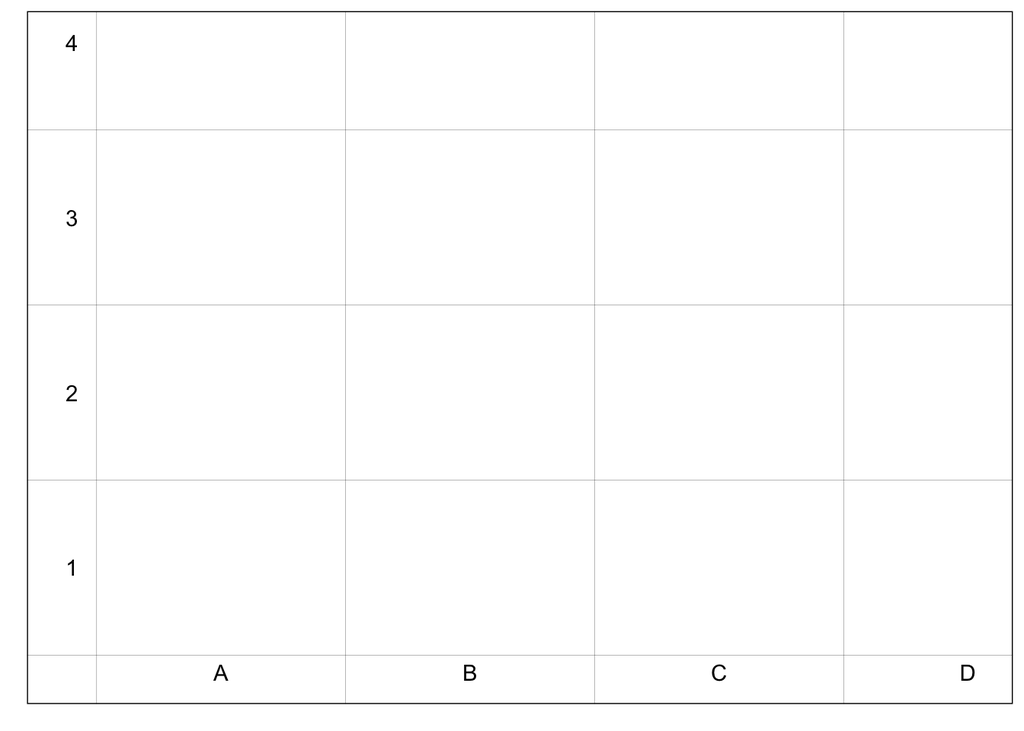

```r
plan <- ggplot2::ggplot() +
    # ces deux premières lignes définissent le thème graphique de la figure
  theme_linedraw() +
  theme(axis.ticks = element_blank(),
        axis.text.x = element_blank(),
        axis.text.y = element_blank(),
        panel.grid.major = element_line(),
        panel.grid.minor = element_blank()) +
  # ensuite, on définit les dimensions des axes :
  # de 0 à 400 cm, avec la même échelle en x et en y (ratio = 1),
  # puis en subdivisant les axes tous les 1 m
  #scale_x_continuous(limits=c(0, 400), breaks = seq(0, 400, by = 100)) +
  #scale_y_continuous(limits=c(0, 400), breaks = seq(0, 400, by = 100)) +
  # enfin, ici on définit les labels des axes
  ylab(element_blank()) +
  xlab(element_blank()) +
  annotate (geom = "text", x = c(seq(from = 50, to = 400, by = 100)), y = -10, label = carres.x) +
  annotate (geom = "text", x = -10, y = c(seq(from = 50, to = 400, by = 100)), label = carres.y)
plan
```

Nous pouvons à présent rajouter les points correspondant aux objets ainsi qu’un titre.

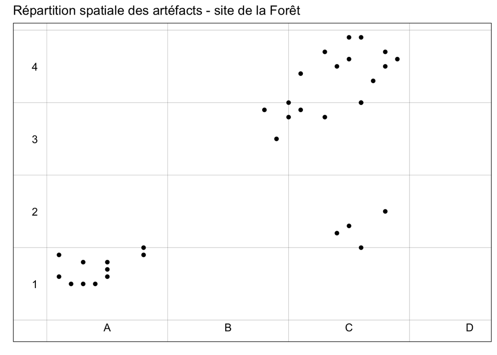

```r
plan +
  geom_point(data = jdd, mapping = aes(x = x_cm, y = y_cm)) +
  labs(title = "Répartition spatiale des artéfacts - site de la Forêt")
```

La figure s’affiche dans l’onglet `plot`, nous pouvons donc suivre son évolution au fur et à mesure des modifications que l’on souhaite y apporter par la suite !

Ce plan reste toutefois peu informatif sur l’organisation des objets dans le site. Il est possible d’améliorer la figure en faisant varier la forme et la couleur des points en fonction des données qualitatives associées à chaque pièce.

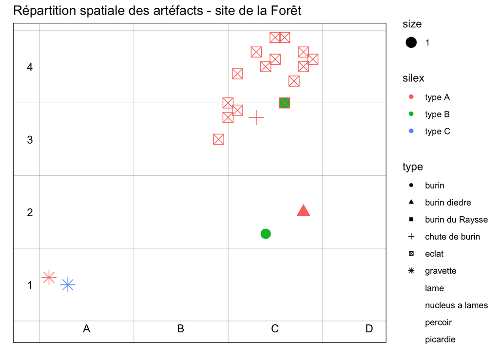

```r
plan +
  geom_point(data = jdd, mapping = aes(x = x_cm, y = y_cm,
                                       color = silex, shape = type,
                                       size = 1)) + # on augmente un peu la taille des points pour plus de lisibilité !
  labs(title = "Répartition spatiale des artéfacts - site de la Forêt")
```

Malheureusement… la palette automatique ne contient pas assez de formes ! Nous allons donc devoir les définir manuellement dans les esthétiques de la figure. Pour cela nous allons attribuer à chaque valeur de `type` une forme.

Affichons pour commencer les levels de `type` (après l’avoir converti en factor).

```r
jdd$type_fac <- factor(jdd$type,
                        # Généralement, les levels sont dans l'ordre alphabétique ; il est possible de changer leur   ordre si vous le voulez !
                       levels = c("nucleus a eclats laminaires", "burin du Raysse",
                                  "eclat", "lame", "chute de burin", "burin",
                                  "burin diedre", "percoir", "picardie", "gravette"))
levels(jdd$type_fac)
```

```
##  [1] "nucleus a eclats laminaires" "burin du Raysse"
##  [3] "eclat"                       "lame"
##  [5] "chute de burin"              "burin"
##  [7] "burin diedre"                "percoir"
##  [9] "picardie"                    "gravette"
```

On créé ensuite manuellement la palette de formes avec `scale_shape_manual`

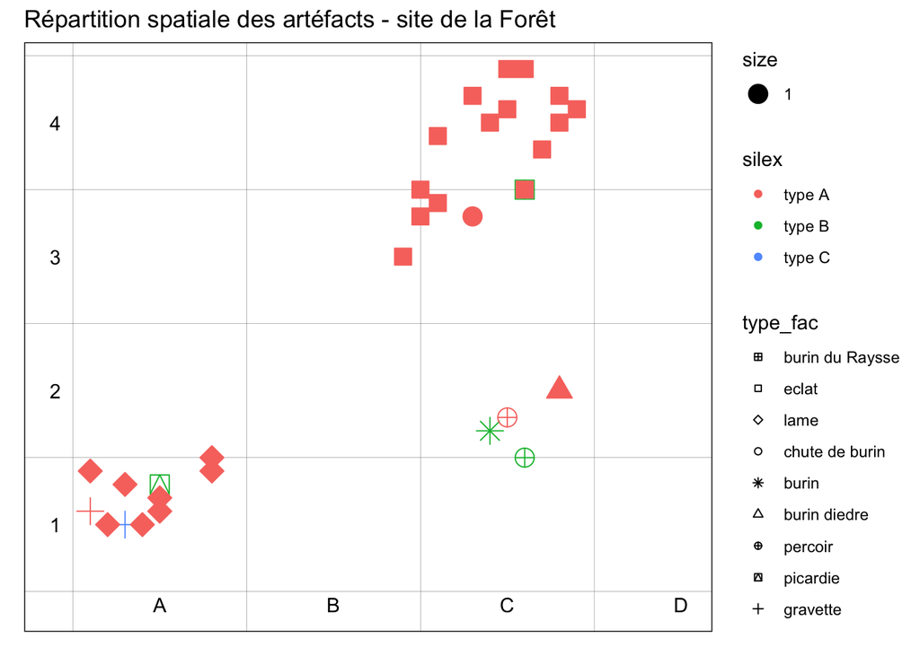

```r
plan +
  geom_point(data = jdd, mapping = aes(x = x_cm, y = y_cm, color = silex,
                                       fill = silex, shape = type_fac, size = 1)) +
  scale_shape_manual(values = c("nucleus a eclats laminaires" = 7,
                                "burin du Raysse" = 12, "eclat" = 22, "lame" = 23,
                                "chute de burin" = 21, "burin" = 8,
                                "burin diedre" = 24, "percoir" = 10,
                                "picardie" = 14, "gravette" = 3)) +
  labs(title = "Répartition spatiale des artéfacts - site de la Forêt")
```

On peut aussi faire la même chose pour la palette de couleurs. Ici je vais utiliser les couleurs de la palette `viridis`.

```r
# Ne pas oublier de convertir en factor !
jdd$silex_fac <- as.factor(jdd$silex)
levels(jdd$silex_fac)
```

```
## [1] "type A" "type B" "type C"
```

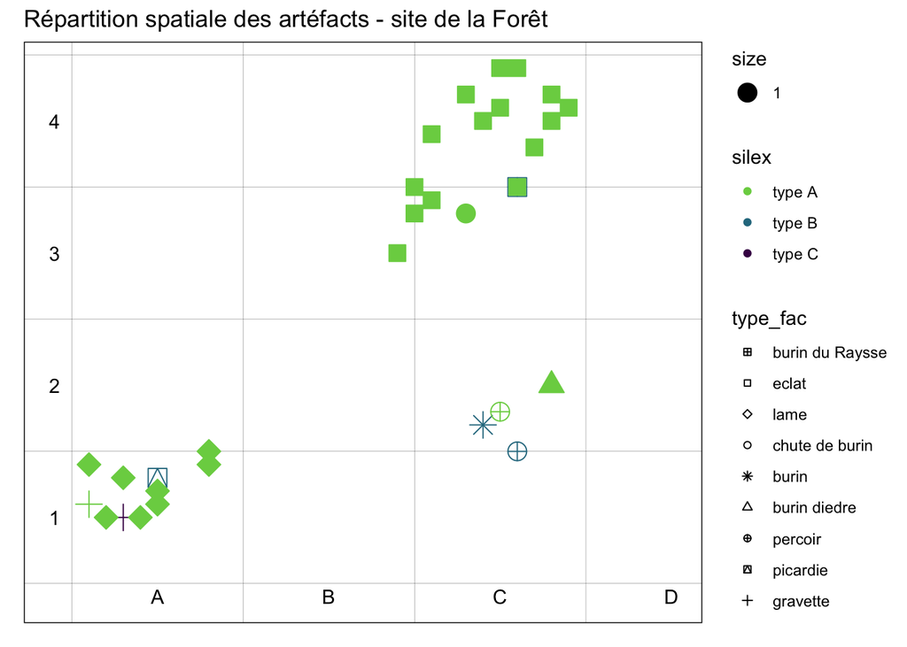

```r
plan +
  geom_point(data = jdd, mapping = aes(x = x_cm, y = y_cm, color = silex,
                                       fill = silex, shape = type_fac, size = 1)) +
  scale_shape_manual(values = c("nucleus a eclats laminaires" = 7,
                                "burin du Raysse" = 12, "eclat" = 22, "lame" = 23,
                                "chute de burin" = 21, "burin" = 8,
                                "burin diedre" = 24, "percoir" = 10,
                                "picardie" = 14, "gravette" = 3)) +
  scale_color_manual(values = c("type A" = "#7AD151FF", "type B" = "#2A788EFF",
                                "type C" = "#440154FF")) +
  scale_fill_manual(values = c("type A" = "#7AD151FF", "type B" = "#2A788EFF",
                               "type C" = "#440154FF")) +
  labs(title = "Répartition spatiale des artéfacts - site de la Forêt")
```

La figure est un peu plus facile à comprendre, mais le code pour la produire n’est pas très efficace… remarquez qu’il y a des répétitions (entre les l.178 et 180) et le fait de définir les palettes dans les fonctions complique la lecture.

Pour clarifier tout cela, nous pouvons créer des `objets` qui contiennent nos palettes. Nous n’aurons ensuite qu’à les appeler dans la fonction.

```r
shape.pal <- c("nucleus a eclats laminaires" = 7, "burin du Raysse" = 12,
               "eclat" = 22, "lame" = 23, "chute de burin" = 21, "burin" = 8,
               "burin diedre" = 24, "percoir" = 10, "picardie" = 14,
               "gravette" = 3)
color.pal <- c("type A" = "#7AD151FF", "type B" = "#2A788EFF", "type C" = "#440154FF")
```

Pour alléger encore, on place les palettes et le titre dans l’objet `plan` de base.

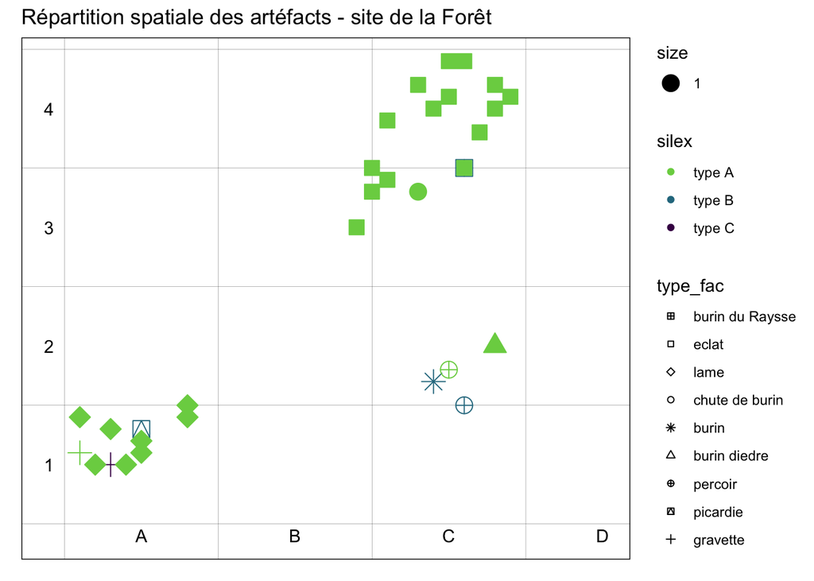

```r
plan.modif <- plan +
  scale_shape_manual(values = shape.pal) +
  scale_color_manual(values = color.pal) +
  scale_fill_manual(values = color.pal) +
  labs(title = "Répartition spatiale des artéfacts - site de la Forêt")

plan.modif +
geom_point(data = jdd, mapping = aes(x = x_cm, y = y_cm, color = silex,
                                     fill = silex, shape = type_fac, size = 1)) # Même résultat !
```

Modifions à présent la légende pour la rendre plus lisible

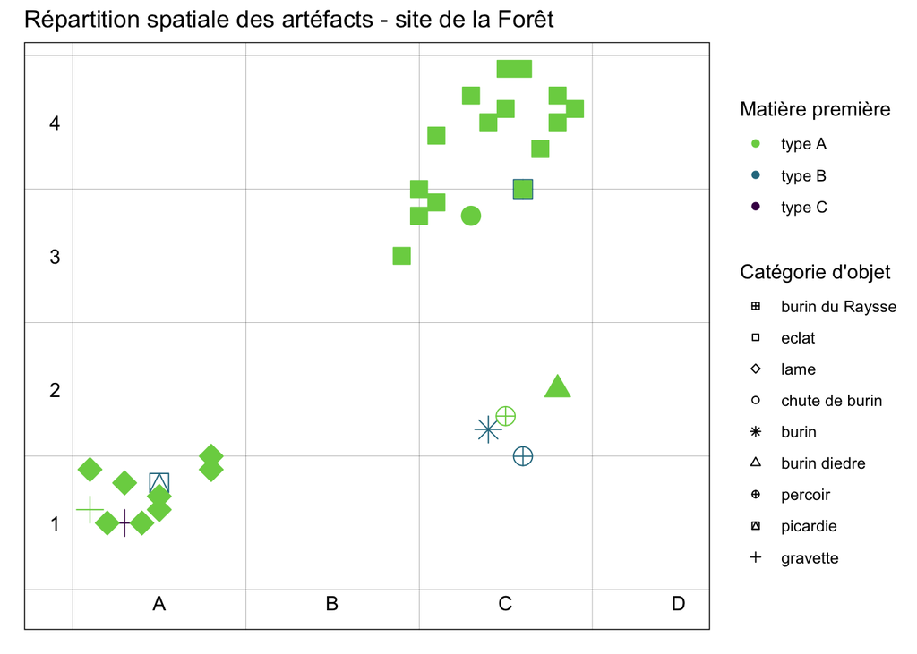

```r
plan.modif +
  geom_point(data = jdd, mapping = aes(x = x_cm, y = y_cm, color = silex,
                                       fill = silex, shape = type_fac, size = 1)) +
    # ici on va changer le titre des légendes
  labs(color = "Matière première", shape = "Catégorie d'objet") +
    # et là, nous pouvons supprimer les légendes que nous ne souhaitons pas voir apparaître dans la figure finale.
  guides(fill = "none", size = "none")
```

# 3 - Sélectionner des données à afficher

Dans cette nouvelle partie, nous allons apprendre comment sélectionner une partie des données, dans l’idée d’un requêtage permettant ensuite d’afficher une portion seulement des données initiales. Cette opération est très pratique par exemple pour réaliser des projections localisées sans avoir à modifier le tableau excel de base, ce qui est plus transparent et permet de limiter les erreurs possibles.

Découvrons comment mettre en oeuvre cette opération. Dans les quelques lignes suivantes, nous allons sélectionner les pièces qui ont fait l’objet d’un raccord ou d’un remontage afin de représenter la relation entre les pièces sur le plan.

Pour cela, nous allons créer un nouveau dataframe dans lequel nous allons “ranger” uniquement les lignes qui contiennent des données pour la variable `raccord`

```r
# faisable avec la fonction is.na()
rac <- jdd[rowSums(is.na(jdd)) == 0,]

# aussi faisable avec la fonction complete.cases()
rac <- jdd[complete.cases(jdd$raccord), ]
```

Les **crochets** permettent de dire à R que l’on va sélectionner des lignes (premier argument) ou des colonnes (deuxième argument) dans le data frame `jdd`. La fonction `complete.cases()` permet ensuite de repérer les cases qui ne sont pas vides. Cette ligne de code nous permet donc de sélectionner dans `jdd` les lignes pour lesquelles la valeur de raccord est renseignée.

Observons ce que cela donne :

```r
head(jdd)
```

```
## # A tibble: 6 × 10
##   numero type          x_cm  y_cm longue…¹ large…² silex raccord type_…³ silex…⁴
##    <int> <chr>        <int> <int>    <dbl>   <dbl> <chr>   <int> <fct>   <fct>
## 1      1 gravette        10    60      5       1.5 type…      NA gravet… type A
## 2      2 gravette        30    50      5.9     1.8 type…      NA gravet… type C
## 3      3 picardie        50    80      3.2     1.2 type…       1 picard… type B
## 4      4 percoir        260   100      4.7     2.1 type…      NA percoir type B
## 5      5 burin          240   120      6       2.4 type…       2 burin   type B
## 6      6 burin diedre   280   150      8       3.5 type…      NA burin … type A
## # … with abbreviated variable names ¹longueur_cm, ²largeur_cm, ³type_fac,
## #   ⁴silex_fac
```

```r
head(rac)
```

```
## # A tibble: 4 × 10
##   numero type           x_cm  y_cm longu…¹ large…² silex raccord type_…³ silex…⁴
##    <int> <chr>         <int> <int>   <dbl>   <dbl> <chr>   <int> <fct>   <fct>
## 1      3 picardie         50    80     3.2     1.2 type…       1 picard… type B
## 2      5 burin           240   120     6       2.4 type…       2 burin   type B
## 3      8 burin du Ray…   260   300     5.3     3.8 type…       1 burin … type B
## 4      9 chute de bur…   230   280     2       0.5 type…       2 chute … type A
## # … with abbreviated variable names ¹longueur_cm, ²largeur_cm, ³type_fac,
## #   ⁴silex_fac
```

Dans la data frame `jdd`, notez bien la présence de cases vides (`NA`) dans la colonne `raccord`. En revanche dans `rac`, seules les lignes pour lesquelles la valeur de `raccord` est renseignée (1 ou 2 en l’occurrence) sont présentes. Il n’y a donc que 4 pièces concernées.

Nous pouvons maintenant rajouter un lien entre les pièces en utilisant cette nouvelle data frame.

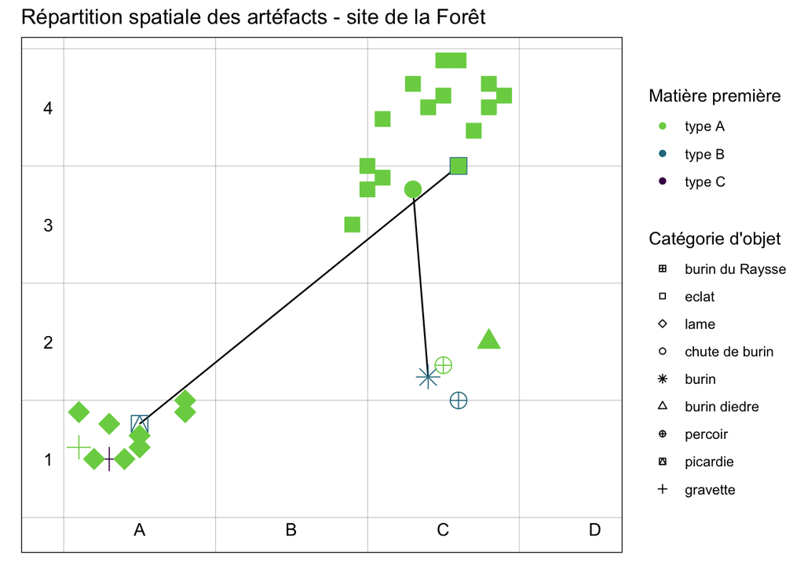

```r
plan.modif +
  geom_line(data = rac, mapping = aes(x = x_cm, y = y_cm, group = raccord),
            linewidth = 0.5) + # l'argument 'group' permet de relier les pièces
                               # par groupe de mêmes valeurs
  geom_point(data = jdd, mapping = aes(x = x_cm, y = y_cm, color = silex,
                                       fill = silex, shape = type_fac, size = 1)) +
    # légende
  labs(color = "Matière première", shape = "Catégorie d'objet") +
  guides(fill = "none", size = "none")
```

Une autre façon de faire des sélections au sein d’une data frame est d’utiliser la fonction `subset()`. Cette fonction permet d’introduire des conditions plus complexes pour la sélection de lignes ou de colonnes, en utilisant des connecteurs logiques.

Par exemple, essayons de sélectionner les pièces situées entre 200 et 400 cm en x, et entre 300 et 500 cm en y.

```r
jdd.zoom <- subset(jdd, x_cm >= 200 & x_cm <= 400
                      & y_cm >= 300 & y_cm <= 500)
```

Pour créer `jdd zoom`, nous demandons R de renvoyer les lignes du data frame dont le x est supérieur ou égal (>=) à 200 ET (&) inférieur ou égal (<=) à 400 ET (&) dont le xy est supérieur ou égal (>=) à 300 ET (&) inférieur ou égal (<=) à 500.

Voyons le résultat sur le plan

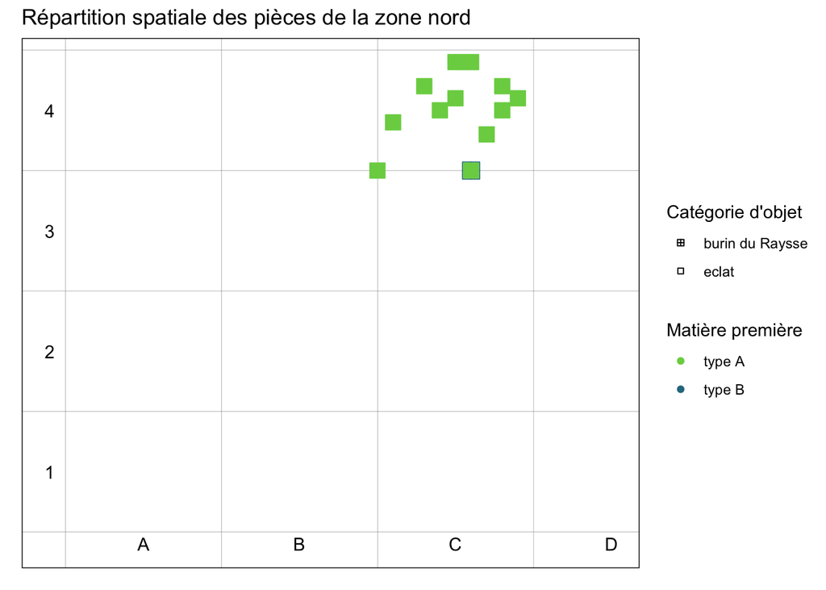

```r
plan.modif +
  geom_point(data = jdd.zoom, mapping = aes(x = x_cm, y = y_cm, color = silex,
                                            fill = silex, shape = type_fac, size = 1)) +
    # titre et légende
  labs(title = "Répartition spatiale des pièces de la zone nord",
       color = "Matière première", shape = "Catégorie d'objet") +
  guides(fill = "none", size = "none")
```

FELICITATIONS ! Vous avez fait vos premiers plots avec ggplot !!